# Calculating Frequency Band Power

Leandro Ledesma

2024-03-12

# Read Cohen’s book to remind myself what this all is

### Universal block code settings

```r
knitr::opts_chunk$set(echo = TRUE)
knitr::opts_chunk$set(message = FALSE)
knitr::opts_chunk$set(comment = NULL)
```

### Load in the data manipulation packages first

```r
library(tidyverse)
library(ggplot2)
library(ggpubr)
library(readxl)
library(kableExtra)
```

### Load in the data

First we will load in the ID’s (including those discovered through fuzzy matching) of the rsEEG data that survived the preprocessing stage. There should 466 of them. Each file read will have an ID variable added that comes from the name of the file. However, it seems only 462 make the final cut.

```r
# set the working directory for rsEEG files that survived the preprocessing stage
setwd("C:/Users/lledesma.TIMES/Documents/Masters Project")

# Load in the ID's
eeg.IDs.survived <- read.csv("Preprocessed.rsEEG.csv") %>% unlist()

# Set the working directory
setwd("Y:/STUDY 1/All EEG Files Organized/Preprocessed_RAW/RAW_eyes_open_and_eyes_closed_FFT")

# list all of the rsEEG files that have FFT data
all.FFT.files <- list.files()

# Record all of the file names in this directory that contain the ID's from above that survived
FFT.files.list <- list()

for(ii in 1:length(eeg.IDs.survived)) {

  # Isolate the current EEG file you are trying to find
  current.pattern = eeg.IDs.survived[ii]

  # Use that current EEG file to find the proper name from all the FFT files
  current.file <- all.FFT.files[grepl(pattern = current.pattern,
                                      x = all.FFT.files)]

  # Equaling the current.file to 1 prevents the following two errors
  # a) loading in a file that survived preprocessing but was not present in FFT
  # b) loading in two files that share the same ID because of tester error
  if(length(current.file) == 1 ) {

  # Read in the file and save it as an object
  setwd("Y:/STUDY 1/All EEG Files Organized/Preprocessed_RAW/RAW_eyes_open_and_eyes_closed_FFT")
  read.file <-  read.csv(current.file)

  # Give this file an ID variable and place it in the front
  read.file <- read.file %>%
    mutate(ID = as.numeric(gsub("\\D", "", current.file))) %>%
    select(ID, Channels, everything())

  # Read that FFT file in and save it into the list
  FFT.files.list[[ii]] <- read.file

  }
}
```

### Explore the FFT data

Each file has 180 variables and 62 rows. The rows represent the electrical activity from a channel, and there are 62 unique channels. We can group them later by topographical location. The variables, on the other hand, that have x followed by a number represent the power of that frequency band. It starts at .5 Hz and goes up by .25 Hz until it reaches 45Hz. The numbers in the cells represent power.

What we can do for a quick quality control check is to just pick a channel and then plot the values across the spectrum using ggplot. We will use Cz.

```r
# Save one of the FFT datasets from the list
current.data <- FFT.files.list[[3]]

# Obtain the dimensions
dim(current.data)
```

```
[1]  62 181
```

```r
# view the first few rows and first 10 variables
head(current.data)[1:10] %>%
  kbl() %>%
  kable_paper(bootstrap_options = "striped", full_width = F)
```

| ID | Channels | x0.5 | x0.75 | x1 | x1.25 | x1.5 | x1.75 | x2 | x2.25 |
| --- | --- | --- | --- | --- | --- | --- | --- | --- | --- |
| 10510 | Fp1 | 1.779144 | 1.828207 | 1.393715 | 1.309518 | 1.0983058 | 1.1788034 | 0.9551549 | 0.9024120 |
| 10510 | Fz | 2.170027 | 1.893075 | 1.726939 | 1.454525 | 1.2462342 | 1.2879235 | 1.0743211 | 0.9659239 |
| 10510 | F3 | 2.013648 | 1.814194 | 1.533448 | 1.392845 | 1.1476202 | 1.2846761 | 1.1282533 | 0.9182845 |
| 10510 | F7 | 1.763305 | 1.827630 | 1.396151 | 1.307186 | 1.1504424 | 1.2797549 | 0.9461670 | 0.8514588 |
| 10510 | FT9 | 2.150545 | 2.148193 | 1.732414 | 1.449547 | 1.4247275 | 1.4465467 | 1.0922184 | 1.0785405 |
| 10510 | FC5 | 1.285501 | 1.362907 | 1.107197 | 0.892248 | 0.8063708 | 0.9355177 | 0.7641644 | 0.6074506 |

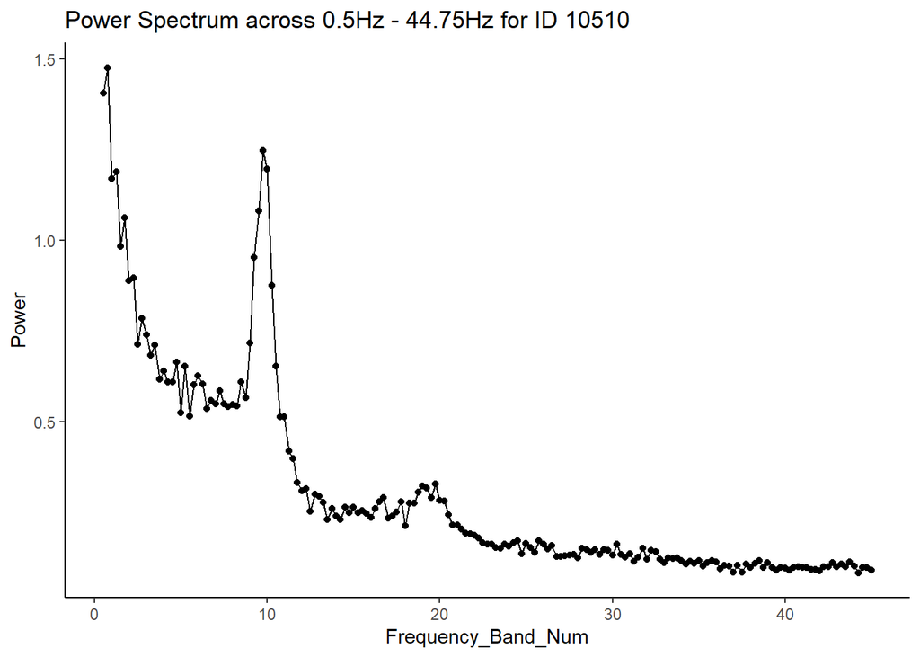

```r
# plot the power spectrum of a subject using channel
Cz.data <- current.data %>%
  filter(Channels == "Cz")

Cz.data.long <- Cz.data %>%
  pivot_longer(cols = - c(ID,Channels),
               names_to = "Frequency_Band_Num",
               values_to = "Power") %>%
  mutate(Frequency_Band_Num = gsub(pattern = "x",
                               x = Frequency_Band_Num,
                               replacement = ''),
         Frequency_Band_Num = as.numeric(Frequency_Band_Num))

Cz.data.long %>%
  ggplot(aes(x = Frequency_Band_Num, y = Power, group = 1)) +
  geom_point() +
  geom_line() +
  theme_classic() +
  labs(title = "Power Spectrum across 0.5Hz - 44.75Hz for ID 10510")
```

### Reducing data dimensionality (Frequency Bands)

Our next step is to take every FFT file and average the power for each frequency band. Doing this will turn our number of variables from 180 to 6, which include the following:

- Channels
- Delta (0.5-4Hz)
- Theta (4-8Hz)
- Alpha (8-12Hz)
- Beta (12-30Hz)
- Gamma (30-45Hz)

This is how we will write it up by every frequency band ends at .75 of the previous whole number. Before we start, we will take our list of subjects and combine them into one major list

```r
# Take all of the FFT files in the list and convert them into one
FFT.files <- FFT.files.list %>%
  do.call(rbind,.)

# Quality check to see what ID's are present
length(unique(FFT.files$ID))
```

```
[1] 462
```

```r
# Convert the data into long format
FFT.files.long <- FFT.files %>%
  pivot_longer(cols = - c(ID, Channels),
               names_to = "Frequency_Band_Num",
               values_to = "Power") %>%
  mutate(Frequency_Band_Num = gsub(pattern = "x",
                               x = Frequency_Band_Num,
                               replacement = ''),
         Frequency_Band_Num = as.numeric(Frequency_Band_Num))

# Create a variable that categorizes the frequency band num into one of the typical bands seen in the literature
FFT.files.averged.frequency.band <- FFT.files.long %>%
  mutate(Frequency_Band = case_when(

    between(FFT.files.long$Frequency_Band_Num, 0, 3.75) ~ 'delta',
    between(FFT.files.long$Frequency_Band_Num, 4, 7.75) ~ 'theta',
    between(FFT.files.long$Frequency_Band_Num, 8, 11.75) ~ 'alpha',
    between(FFT.files.long$Frequency_Band_Num, 12, 29.75) ~ 'beta',
    TRUE ~ 'gamma'

    ))

# Group the data by ID, and channels and by frequency band, then get the averaged power for each of these groupings
averaged.ID.frequency.band.power <- FFT.files.averged.frequency.band %>%
  group_by(ID, Channels, Frequency_Band) %>%
  summarize(avg_power = mean(Power))

# Let's get the new dimensions
dim(averaged.ID.frequency.band.power)
```

```
[1] 143220      4
```

### Reducing data dimensionality (Channels)

The next thing we want to do is to group up the channels based on topographical location. We will transform our 62 channels into the following 5 categorical values:

```r
# Create vectors that correspond to the channels topographical location
frontal <- c("AF3", "AF4", "AF7", "AF8", "AFz", "F1", "F2", "F3", "F4", "F5", "F6", "F7", "F8", "Fz", "Fp1", "Fp2")
central <- c("FC1", "FC2", "FC3", "FC4", "FC5", "FC6", "FCz", "C1",   "C2", "C3", "C4", "C5", "C6", "Cz","CP1", "CP2", "CP3", "CP4", "CP5", "CP6", "CPz")
temporal <- c("FT10", "FT7",  "FT8",  "FT9", "T7", "T8",  "TP7", "TP8")
parietal <- c("P1", "P2", "P3",  "P4",  "P5",  "P6",  "P7",  "P8", "Pz")
occipital <- c("O1", "O2", "Oz", "PO3", "PO4", "PO7", "PO8", "POz")

# Create a variable that categorizes the frequency band num into one of the typical bands seen in the literature
final.data.long <- averaged.ID.frequency.band.power %>%
  mutate(Topography = case_when(

    Channels %in% frontal ~ 'frontal',
    Channels %in% central ~ 'central',
    Channels %in% temporal ~ 'temporal',
    Channels %in% parietal ~ 'parietal',
    Channels %in% occipital ~ 'occipital',
    TRUE ~ 'Not Used'

    ))

# Quality check to see if any channels were not assigned to a topographical group
final.data.long %>%
  filter(Topography == "Not Used") %>%
  ungroup() %>%
  select(Channels) %>%
  unique()
```

```
# A tibble: 0 × 1
# … with 1 variable: Channels <chr>
```

```r
# Group the data by ID, topography and by frequency band, then get the averaged power for each of these groupings
final.data <- final.data.long %>%
  group_by(ID, Topography, Frequency_Band) %>%
  summarize(avg_power = mean(avg_power))

# Let's get the new dimensions
dim(final.data)
```

```
[1] 11550     4
```

For every person (462) there is the averaged power for frequency bands (5) and topographical location (5), which equals to 462 x 5 x 5 = 11550 rows.

### Quality Control

Now that we have gotten our final data, let’s do some quality control before saving it. We need to figure out how many subjects we have and how many unique topographies are present.

```r
# Check the number of ID's present on our final dataset
length(unique(final.data$ID))
```

```
[1] 462
```

```r
# Check the proportions of topographical locations- they should all be the same
prop.table(table(final.data$Topography))
```

```
  central   frontal occipital  parietal  temporal
      0.2       0.2       0.2       0.2       0.2
```

```r
# Lastly, check the proportions of frequency bands- they should also all be the same
prop.table(table(final.data$Frequency_Band))
```

```
alpha  beta delta gamma theta
  0.2   0.2   0.2   0.2   0.2
```

### Last data transformation

For our dependent variables, which are the information in this data frame, to be used by a statistical code, they need to be in wide format and not long. Thus we will now transfer our data back into a wide format and later deside which rows and columns we want to keep for our final analysis.

Additionally, if we end up not needing to analyze topography, we have also create a data transformation that just averages power across the whole scalp.

```r
# Covert the data into wide
final.data.wide.topography <- final.data %>%
  pivot_wider(names_from = Frequency_Band,
              values_from = avg_power) %>%
  select(ID, Topography, delta, theta, alpha, beta, gamma)

final.data.wide.no.topography <- final.data.wide.topography %>%
  group_by(ID) %>%
  summarize(delta = mean(delta),
            theta = mean(theta),
            alpha = mean(alpha),
            beta = mean(beta),
            gamma = mean(gamma))
```

### Checking the assumptions

Before we are finished- it is good practice for us to know what our data look like (for dependent variables). If they do not look normally distributed, then that would influence which statistical approach we can use. Let’s just look at the histograms for the frequency bands in the non-topographical data. We can graph the others once we figure out what approach we want to take.

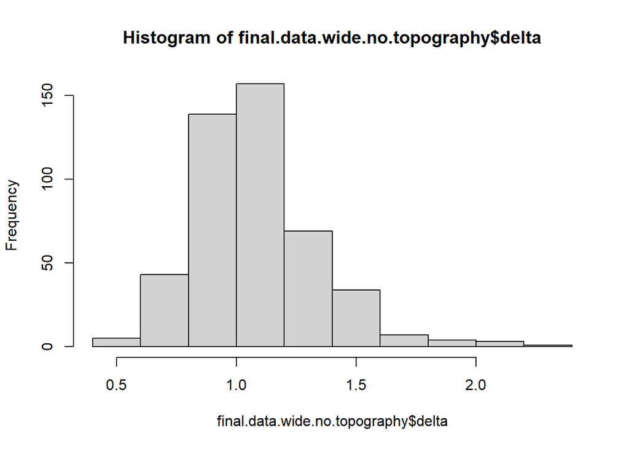

```r
# Graph the power for delta
hist(final.data.wide.no.topography$delta)
```

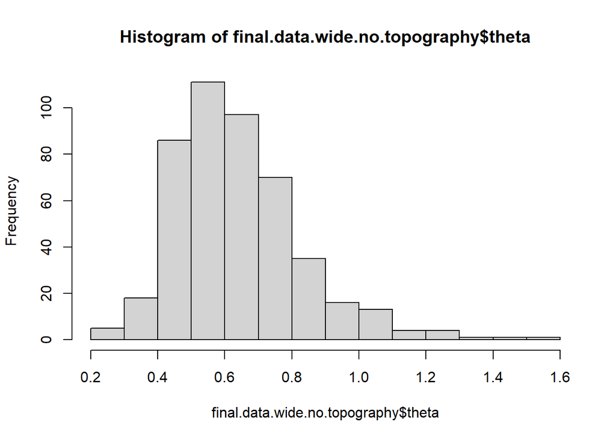

```r
# Graph the power for theta
hist(final.data.wide.no.topography$theta)
```

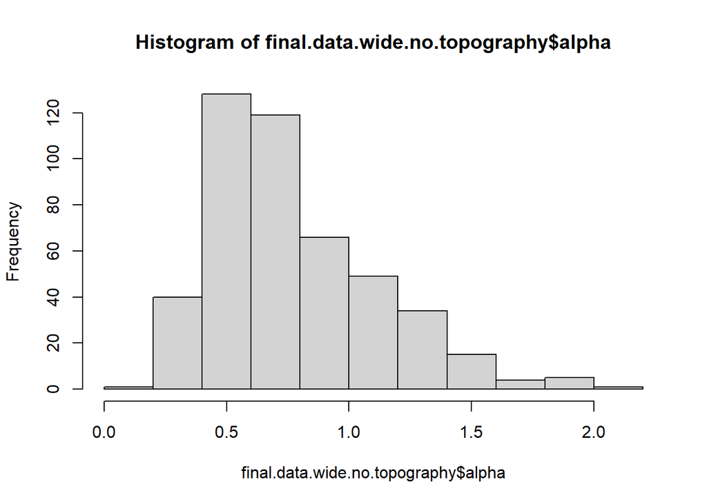

```r
# Graph the power for alpha
hist(final.data.wide.no.topography$alpha)
```

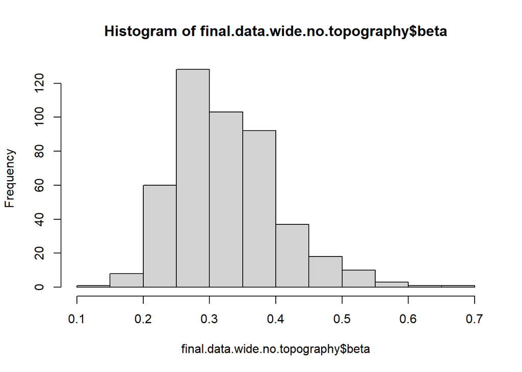

```r
# Graph the power for beta
hist(final.data.wide.no.topography$beta)
```

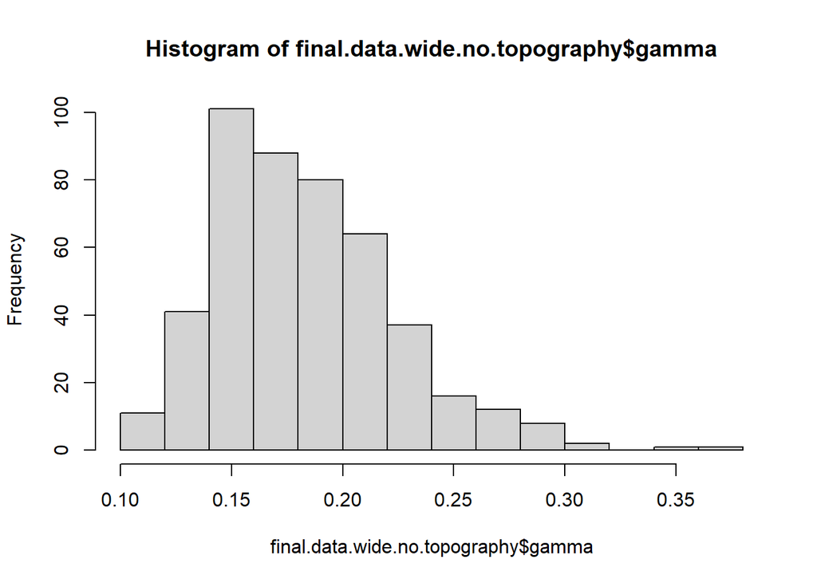

```r
# Graph the power for gamma
hist(final.data.wide.no.topography$gamma)
```

### Saving files

We will be saving this data set as one large CSV file to be joined with our predictor variables in the next code.

```r
# Set the saving directory
setwd("~/Masters Project/cleaned_dependent_variable")

# Save the 462 files with topography
write_csv(final.data.wide.topography, file = "Frequency.Bands.Topography.csv")

# Save the 462 files without topography
write_csv(final.data.wide.no.topography, file = "Frequency.Bands.No.Topography.csv")
```